# act_report

## Report: act_report

- Create a **250-word-minimum written report** called "act_report.pdf" or "act_report.html" that communicates the insights and displays the visualization(s) produced from your wrangled data. This is to be framed as an external document, like a blog post or magazine article, for example.

## Analysis Description

The cleaned WeRateDogs twitter data was used to come up with the following analyses and visualizations.

### 1. Most common dog stage

To analyze this, we need to plot a bar graph. The most common dog type is pupper with a total of 206 dogs, then followed by doggo with a total of 63 dogs. However, there are several dog stage names that were invalid (None values). Therefore, this result might be affected when one can obtain the actual dog stage for the none values.

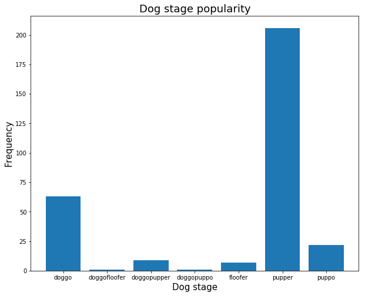

### 2. Top 5 dog breeds by total retweet count

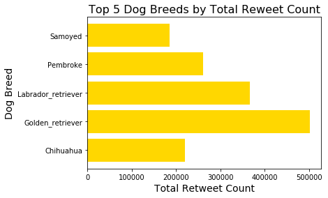

### 3. Relationship between favorite_count and retweet_count

To analyse the relationship between favorite count and retweet count, we need to plot a scatter plot. From the scatter plot, it is clear that there is a very positive linear relationship between number of favorite count and number of retweet count for a given tweet. This is true since, in twitter, it is common for favorite tweets to receive most retweets.

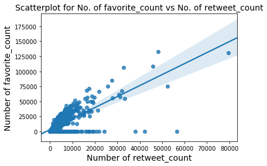

### 4. Ratings Distribution

We need to know how the dogs were rated on twitter. This analysis can be done by determining the value counts for each ratings. The most popular rating for the numerator is 12.0 while the most popular rating for the denominator is 10.0